# R语言统计与建模

# 第七章：面板数据模型

面板数据（Panel Data）是同时在时间和个体维度上观测的数据，广泛应用于经济学、医学研究等领域。本章将系统讲解固定效应、随机效应、动态面板等模型。

## 7.1 面板数据结构

### 意义与使用场景

**核心意义**：面板数据同时包含截面维度（个体）和时间维度，能够控制不可观测的个体异质性，提高估计效率。

**举例**：多中心临床试验的长期随访数据

**为什么这种数据适合用面板数据模型？**

首先，数据同时在多个中心（个体维度）和多个时间点（时间维度）上观测，形成面板数据结构。其次，不同中心可能存在不可观测的异质性（如医疗水平、患者人群差异），传统截面方法无法控制。面板数据模型能够控制个体固定效应，消除异质性偏差，提高估计效率。

**研究目的是什么？**

本研究有三个层次的目的：1. 控制个体异质性：消除各中心不可观测差异带来的偏差；2. 利用面板优势：增加样本量，提高估计精度；3. 识别动态效应：分析治疗效果随时间的变化。

**可能得到什么样的结果？**

假设面板数据分析显示：固定效应模型R²=0.75，治疗效应β=0.35（p<0.001）。

1. 数据结构：50个中心，每个中心10年随访，共500个观测，平衡面板。
2. 个体异质性：各中心的截距差异显著（F检验p<0.001），说明存在个体固定效应。
3. 治疗效应：控制中心固定效应后，治疗效果β=0.35，比混合回归估计（β=0.45）更准确。
4. 时间效应：治疗效果随时间增强，第5年后效果趋于稳定。

**需要注意什么？**

面板数据需区分平衡面板和非平衡面板，非平衡面板可能存在选择偏差。固定效应模型只能估计时变变量的效应，无法估计时不变变量（如性别、种族）。面板数据的样本量计算需考虑个体数和时间期的双重影响。

### 数学基础

**面板数据特点**：

- **截面维度**：$N$个个体
- **时间维度**：$T$个时期
- **平衡面板**：每个个体都有完整的$T$期观测
- **非平衡面板**：部分个体有缺失观测

**数据结构**：

$$Y_{it} = \alpha_i + \beta X_{it} +
\varepsilon_{it}$$

**参数说明**： - $i$：个体下标 - $t$：时间下标 - $\alpha_i$：个体固定效应

### 代码实现

```r
# 模拟面板数据
set.seed(111)
n_individuals <- 50
n_periods <- 10

# 生成面板数据
panel_data <- data.frame(
  id = rep(1:n_individuals, each = n_periods),
  time = rep(1:n_periods, n_individuals)
)

# 生成个体固定效应
individual_effect <- rnorm(n_individuals, 0, 3)
panel_data$alpha_i <- individual_effect[panel_data$id]

# 生成自变量
panel_data$x1 <- rnorm(nrow(panel_data), 50, 10) + panel_data$alpha_i * 0.5
panel_data$x2 <- rnorm(nrow(panel_data), 100, 20)

# 生成因变量
panel_data$y <- 10 + 0.5 * panel_data$x1 + 0.3 * panel_data$x2 +
                panel_data$alpha_i + rnorm(nrow(panel_data), 0, 2)

# 查看数据结构
str(panel_data)
```

```
## 'data.frame':    500 obs. of  6 variables:
##  $ id     : int  1 1 1 1 1 1 1 1 1 1 ...
##  $ time   : int  1 2 3 4 5 6 7 8 9 10 ...
##  $ alpha_i: num  0.706 0.706 0.706 0.706 0.706 ...
##  $ x1     : num  52.3 65.9 59.5 53.9 52.1 ...
##  $ x2     : num  81.1 91.6 66.7 119.2 97.6 ...
##  $ y      : num  62.3 66.9 60.4 74.5 68.4 ...
```

```r
head(panel_data, 15)
```

```
##    id time    alpha_i       x1        x2        y
## 1   1    1  0.7056621 52.26946  81.13040 62.27035
## 2   1    2  0.7056621 65.87827  91.60649 66.86542
## 3   1    3  0.7056621 59.49525  66.65784 60.40834
## 4   1    4  0.7056621 53.93908 119.24568 74.45950
## 5   1    5  0.7056621 52.10379  97.59034 68.35469
## 6   1    6  0.7056621 41.88015 115.12986 67.65765
## 7   1    7  0.7056621 60.13515  86.04346 67.99838
## 8   1    8  0.7056621 68.41151 106.80401 78.32145
## 9   1    9  0.7056621 51.58198 128.89678 74.39321
## 10  1   10  0.7056621 49.05511 117.86020 71.52604
## 11  2    1 -0.9922076 47.33961 107.89379 60.33753
## 12  2    2 -0.9922076 63.96868 109.15645 73.01814
## 13  2    3 -0.9922076 53.60099  96.04250 65.47151
## 14  2    4 -0.9922076 58.61306 133.01039 79.98570
## 15  2    5 -0.9922076 63.80748  99.26790 77.46338
```

```r
# 使用plm包
library(plm)

# 声明面板数据
pdata <- plm::pdata.frame(panel_data, index = c("id", "time"))
```

## 7.2 固定效应模型

### 意义与使用场景

**核心意义**：固定效应模型通过控制个体固定效应，消除不可观测的个体异质性偏差，得到一致的估计。

**举例**：控制医院固定效应比较治疗效果

**为什么这种数据适合用固定效应模型？**

首先，不同医院可能存在不可观测的异质性（如医疗水平、设备条件），这些因素可能与治疗效果相关。其次，我们关注的是治疗变量（时变变量）的效应，而非医院的特征。固定效应模型通过控制医院固定效应，消除异质性偏差，得到治疗效应的一致估计。

**研究目的是什么？**

本研究有三个层次的目的：1. 控制医院异质性：消除各医院不可观测差异带来的偏差；2. 估计治疗效应：得到治疗变量的无偏估计；3. 检验固定效应：判断固定效应是否显著，选择合适的模型。

**可能得到什么样的结果？**

假设固定效应模型显示：治疗效应β=0.35（p<0.001），固定效应检验F=15.2（p<0.001）。

1. 固定效应检验：F检验p<0.001，拒绝”个体效应为零”的原假设，固定效应模型优于混合回归。
2. 治疗效应：控制医院固定效应后，治疗效应β=0.35，比混合回归（β=0.50）更准确。
3. 组内R²：组内R²=0.72，说明模型解释了72%的组内变异。
4. 时不变变量：医院等级、地理位置等时不变变量无法在固定效应模型中估计。

**需要注意什么？**

固定效应模型只能估计时变变量的效应，无法估计时不变变量（如性别、种族、医院等级）。若需要估计时不变变量，可考虑随机效应模型或混合效应模型。固定效应模型的估计方法包括组内估计和LSDV，两者结果等价但计算效率不同。

### 数学基础

**固定效应模型（FE）**：

$$Y_{it} = \alpha_i + \beta X_{it} +
\varepsilon_{it}$$

**估计方法**：

1. **组内估计（Within Estimator）**：
   $$\tilde{Y}_{it} = \beta \tilde{X}_{it} +
   \tilde{\varepsilon}_{it}$$
   其中$\tilde{Y}_{it} = Y_{it} - \bar{Y}_i$为组内离差。
2. **LSDV（最小二乘虚拟变量法）**： 直接加入个体虚拟变量。

**固定效应检验**：

$$H_0: \alpha_1 = \alpha_2 = \cdots =
\alpha_N = 0$$

### 代码实现

```r
# 混合OLS模型
pooled_model <- plm::plm(y ~ x1 + x2, data = pdata, model = "pooling")
summary(pooled_model)
```

```
## Pooling Model
##
## Call:
## plm::plm(formula = y ~ x1 + x2, data = pdata, model = "pooling")
##
## Balanced Panel: n = 50, T = 10, N = 500
##
## Residuals:
##      Min.   1st Qu.    Median   3rd Qu.      Max.
## -13.48722  -2.65565   0.38046   2.46962  11.32791
##
## Coefficients:
##              Estimate Std. Error t-value  Pr(>|t|)
## (Intercept) 6.2548665  1.2747030  4.9069 1.256e-06 ***
## x1          0.5713839  0.0183153 31.1970 < 2.2e-16 ***
## x2          0.2946080  0.0090006 32.7319 < 2.2e-16 ***
## ---
## Signif. codes:  0 '***' 0.001 '**' 0.01 '*' 0.05 '.' 0.1 ' ' 1
##
## Total Sum of Squares:    42178
## Residual Sum of Squares: 8028
## R-Squared:      0.80966
## Adj. R-Squared: 0.8089
## F-statistic: 1057.08 on 2 and 497 DF, p-value: < 2.22e-16
```

```r
# 固定效应模型（组内估计）
fe_model <- plm::plm(y ~ x1 + x2, data = pdata, model = "within")
summary(fe_model)
```

```
## Oneway (individual) effect Within Model
##
## Call:
## plm::plm(formula = y ~ x1 + x2, data = pdata, model = "within")
##
## Balanced Panel: n = 50, T = 10, N = 500
##
## Residuals:
##      Min.   1st Qu.    Median   3rd Qu.      Max.
## -4.867472 -1.177090  0.062713  1.196818  6.575264
##
## Coefficients:
##     Estimate Std. Error t-value  Pr(>|t|)
## x1 0.5173956  0.0095857  53.976 < 2.2e-16 ***
## x2 0.3029740  0.0045988  65.881 < 2.2e-16 ***
## ---
## Signif. codes:  0 '***' 0.001 '**' 0.01 '*' 0.05 '.' 0.1 ' ' 1
##
## Total Sum of Squares:    30524
## Residual Sum of Squares: 1686.1
## R-Squared:      0.94476
## Adj. R-Squared: 0.93847
## F-statistic: 3831.23 on 2 and 448 DF, p-value: < 2.22e-16
```

```r
# 提取固定效应
fe_effects <- plm::fixef(fe_model)
cat("========== 个体固定效应（前10个） ==========\n")
```

```
## ========== 个体固定效应（前10个） ==========
```

```r
print(head(fe_effects, 10))
```

```
##        1        2        3        4        5        6        7        8
## 9.893385 7.798814 9.105530 1.818202 9.228620 9.239097 4.810655 5.280331
##        9       10
## 5.148118 7.568561
```

```r
# 固定效应检验
fe_test <- plm::pFtest(fe_model, pooled_model)
cat("\n========== 固定效应检验 ==========\n")
```

```
##
## ========== 固定效应检验 ==========
```

```r
print(fe_test)
```

```
##
##  F test for individual effects
##
## data:  y ~ x1 + x2
## F = 34.39, df1 = 49, df2 = 448, p-value < 2.2e-16
## alternative hypothesis: significant effects
```

```r
# LSDV方法
fe_lsdv <- lm(y ~ x1 + x2 + factor(id), data = panel_data)
summary(fe_lsdv)
```

```
##
## Call:
## lm(formula = y ~ x1 + x2 + factor(id), data = panel_data)
##
## Residuals:
##     Min      1Q  Median      3Q     Max
## -4.8675 -1.1771  0.0627  1.1968  6.5753
##
## Coefficients:
##                Estimate Std. Error t value Pr(>|t|)
## (Intercept)    9.893385   0.921104  10.741  < 2e-16 ***
## x1             0.517396   0.009586  53.976  < 2e-16 ***
## x2             0.302974   0.004599  65.881  < 2e-16 ***
## factor(id)2   -2.094571   0.868138  -2.413  0.01623 *
## factor(id)3   -0.787855   0.868332  -0.907  0.36473
## factor(id)4   -8.075183   0.875238  -9.226  < 2e-16 ***
## factor(id)5   -0.664765   0.869842  -0.764  0.44513
## factor(id)6   -0.654288   0.869416  -0.753  0.45211
## factor(id)7   -5.082730   0.871491  -5.832 1.05e-08 ***
## factor(id)8   -4.613054   0.867782  -5.316 1.68e-07 ***
## factor(id)9   -4.745267   0.872760  -5.437 8.92e-08 ***
## factor(id)10  -2.324824   0.867915  -2.679  0.00766 **
## factor(id)11  -2.043770   0.874604  -2.337  0.01989 *
## factor(id)12  -2.055696   0.867668  -2.369  0.01825 *
## factor(id)13   4.166750   0.867790   4.802 2.15e-06 ***
## factor(id)14   0.161556   0.873451   0.185  0.85334
## factor(id)15   1.118020   0.869756   1.285  0.19930
## factor(id)16  -5.497292   0.874587  -6.286 7.76e-10 ***
## factor(id)17  -1.442928   0.867835  -1.663  0.09708 .
## factor(id)18  -1.572085   0.873780  -1.799  0.07266 .
## factor(id)19  -5.539345   0.867911  -6.382 4.36e-10 ***
## factor(id)20  -1.037640   0.867942  -1.196  0.23252
## factor(id)21  -0.334502   0.872257  -0.383  0.70154
## factor(id)22   0.344714   0.868963   0.397  0.69178
## factor(id)23  -1.406438   0.868812  -1.619  0.10619
## factor(id)24  -1.090819   0.868732  -1.256  0.20990
## factor(id)25  -0.246406   0.870750  -0.283  0.77732
## factor(id)26  -0.102563   0.869364  -0.118  0.90614
## factor(id)27  -7.492941   0.871520  -8.598  < 2e-16 ***
## factor(id)28   7.994563   0.869899   9.190  < 2e-16 ***
```

[output cut: 13 more lines]

```
## factor(id)42  -4.250774   0.875401  -4.856 1.66e-06 ***
## factor(id)43  -6.349854   0.871436  -7.287 1.44e-12 ***
## factor(id)44   0.044263   0.873480   0.051  0.95961
## factor(id)45   0.630730   0.867991   0.727  0.46782
## factor(id)46  -0.910107   0.870366  -1.046  0.29628
## factor(id)47  -0.367757   0.869494  -0.423  0.67253
## factor(id)48   0.672493   0.870491   0.773  0.44020
## factor(id)49   6.004634   0.868303   6.915 1.62e-11 ***
## factor(id)50   3.869319   0.869561   4.450 1.09e-05 ***
## ---
## Signif. codes:  0 '***' 0.001 '**' 0.01 '*' 0.05 '.' 0.1 ' ' 1
##
## Residual standard error: 1.94 on 448 degrees of freedom
## Multiple R-squared:   0.96,  Adjusted R-squared:  0.9555
## F-statistic:   211 on 51 and 448 DF,  p-value: < 2.2e-16
```

## 7.3 随机效应模型

### 意义与使用场景

**核心意义**：随机效应模型假设个体效应与解释变量不相关，比固定效应更高效，可估计时不变变量。

**举例**：分析性别、年龄等变量对健康结果的影响

**为什么这种数据适合用随机效应模型？**

首先，我们需要估计时不变变量（如性别、种族）的效应，固定效应模型无法估计。其次，我们假设个体效应与解释变量不相关，即医院的异质性是随机的，与治疗变量无关。随机效应模型能够估计时不变变量的效应，且比固定效应更高效（标准误更小）。

**研究目的是什么？**

本研究有三个层次的目的：1. 估计时不变变量效应：分析性别、种族等变量对健康结果的影响；2. 获得更高效的估计：利用随机效应模型的优势，获得更精确的估计；3. 检验模型假设：通过Hausman检验判断随机效应假设是否成立。

**可能得到什么样的结果？**

假设随机效应模型显示：性别效应β=0.25（p=0.02），治疗效应β=0.38（p<0.001）。

1. 时不变变量：女性比男性健康结果高0.25个单位，差异显著。
2. 治疗效应：治疗效应β=0.38，与固定效应估计（β=0.35）接近。
3. 组内相关系数：ICC=0.35，说明35%的变异来自个体间差异。
4. 模型效率：随机效应的标准误比固定效应小15%，估计更高效。

**需要注意什么？**

随机效应模型的核心假设是个体效应与解释变量不相关。若假设违反，估计将有偏。建议通过Hausman检验判断应使用固定效应还是随机效应模型。随机效应模型可估计时不变变量，但需谨慎解释，确保假设合理。

### 数学基础

**随机效应模型（RE）**：

$$Y_{it} = \alpha + \beta X_{it} + u_i +
\varepsilon_{it}$$

**参数说明**： - $u_i$：随机个体效应，$u_i \sim N(0, \sigma_u^2)$ - $\varepsilon_{it}$：误差项，$\varepsilon_{it} \sim N(0, \sigma_\varepsilon^2)$

**GLS估计**：

广义最小二乘，考虑复合误差结构。

**方差成分**：
$$Var(Y_{it})
= \sigma_u^2 + \sigma_\varepsilon^2$$
$$Cov(Y_{it}, Y_{is}) = \sigma_u^2$$

### 代码实现

```r
# 随机效应模型
re_model <- plm::plm(y ~ x1 + x2, data = pdata, model = "random")
summary(re_model)
```

```
## Oneway (individual) effect Random Effect Model
##    (Swamy-Arora's transformation)
##
## Call:
## plm::plm(formula = y ~ x1 + x2, data = pdata, model = "random")
##
## Balanced Panel: n = 50, T = 10, N = 500
##
## Effects:
##                  var std.dev share
## idiosyncratic  3.764   1.940 0.249
## individual    11.360   3.370 0.751
## theta: 0.8209
##
## Residuals:
##      Min.   1st Qu.    Median   3rd Qu.      Max.
## -5.808529 -1.264999  0.094409  1.360050  6.498766
##
## Coefficients:
##              Estimate Std. Error z-value  Pr(>|z|)
## (Intercept) 8.0267447  0.8111315  9.8957 < 2.2e-16 ***
## x1          0.5194305  0.0096189 54.0010 < 2.2e-16 ***
## x2          0.3026540  0.0046188 65.5266 < 2.2e-16 ***
## ---
## Signif. codes:  0 '***' 0.001 '**' 0.01 '*' 0.05 '.' 0.1 ' ' 1
##
## Total Sum of Squares:    30898
## Residual Sum of Squares: 1894.1
## R-Squared:      0.9387
## Adj. R-Squared: 0.93845
## Chisq: 7610.34 on 2 DF, p-value: < 2.22e-16
```

```r
# 提取方差成分
ercomp <- plm::ercomp(re_model)
cat("========== 方差成分 ==========\n")
```

```
## ========== 方差成分 ==========
```

```r
print(ercomp)
```

```
##                  var std.dev share
## idiosyncratic  3.764   1.940 0.249
## individual    11.360   3.370 0.751
## theta: 0.8209
```

```r
# 计算组内相关系数
icc_panel <- ercomp$sigma2["id"] / (ercomp$sigma2["id"] + ercomp$sigma2["idios"])
cat(sprintf("\n组内相关系数(ICC): %.3f\n", icc_panel))
```

```
##
## 组内相关系数(ICC): 0.751
```

## 7.4 Hausman检验

### 意义与使用场景

**核心意义**：Hausman检验用于在固定效应和随机效应模型之间做出选择，是面板数据分析的关键步骤。

**举例**：决定多中心研究应使用固定效应还是随机效应模型

**为什么这种数据适合用Hausman检验？**

首先，固定效应和随机效应模型各有优势：固定效应无偏但效率低，随机效应高效但可能有偏。其次，我们需要一种统计方法来判断哪种模型更合适。Hausman检验通过比较两种模型的估计差异，判断随机效应假设是否成立，是模型选择的标准方法。

**研究目的是什么？**

本研究有三个层次的目的：1. 比较模型估计：检验固定效应和随机效应模型的估计是否存在显著差异；2. 选择合适模型：根据检验结果选择固定效应或随机效应模型；3. 验证模型假设：判断随机效应假设是否成立。

**可能得到什么样的结果？**

假设Hausman检验显示：卡方=12.5，自由度=2，p值=0.002。

1. 检验结果：p值=0.002<0.05，拒绝原假设，固定效应和随机效应估计存在显著差异。
2. 模型选择：应选择固定效应模型，因为随机效应假设不成立。
3. 估计差异：固定效应估计β=0.35，随机效应估计β=0.45，差异较大。
4. 原因分析：个体效应与解释变量相关，随机效应估计有偏。

**需要注意什么？**

Hausman检验的原假设是随机效应一致且更有效。p值<0.05表示拒绝原假设，应选择固定效应模型；p值≥0.05表示不能拒绝原假设，可选择随机效应模型。检验结果受样本量影响：大样本可能检测到微小差异，小样本可能漏检重要差异。

### 数学基础

**Hausman检验**：

用于选择固定效应还是随机效应模型。

$$H_0:
\text{随机效应一致且更有效}$$
$$H_1:
\text{固定效应一致}$$

**检验统计量**：
$$H =
(\hat{\beta}_{FE} - \hat{\beta}_{RE})' [Var(\hat{\beta}_{FE}) -
Var(\hat{\beta}_{RE})]^{-1} (\hat{\beta}_{FE} -
\hat{\beta}_{RE})$$

在$H_0$下，$H \sim \chi^2(k)$。

### 代码实现

```r
# Hausman检验
hausman_test <- plm::phtest(fe_model, re_model)
cat("========== Hausman检验 ==========\n")
```

```
## ========== Hausman检验 ==========
```

```r
print(hausman_test)
```

```
##
##  Hausman Test
##
## data:  y ~ x1 + x2
## chisq = 7.2345, df = 2, p-value = 0.02686
## alternative hypothesis: one model is inconsistent
```

```r
# 解释
if (hausman_test$p.value < 0.05) {
  cat("\n结论：拒绝原假设，应使用固定效应模型\n")
} else {
  cat("\n结论：不能拒绝原假设，可使用随机效应模型\n")
}
```

```
##
## 结论：拒绝原假设，应使用固定效应模型
```

## 7.5 动态面板模型

### 意义与使用场景

**核心意义**：动态面板模型处理因变量滞后项导致的内生性问题，使用工具变量方法获得一致估计。

**举例**：分析健康状态的动态调整过程

**为什么这种数据适合用动态面板模型？**

首先，健康状态具有持续性：本期健康状态可能与上期健康状态相关（路径依赖）。其次，模型中包含因变量滞后项会导致内生性问题：滞后项与个体固定效应相关，普通固定效应估计有偏。动态面板模型（如Arellano-Bond GMM）使用工具变量方法，能够获得一致估计。

**研究目的是什么？**

本研究有三个层次的目的：1. 建模动态调整：分析健康状态的持续性和调整过程；2. 处理内生性：解决因变量滞后项导致的内生性问题；3. 检验工具变量有效性：通过Sargan检验和序列相关检验验证模型设定。

**可能得到什么样的结果？**

假设动态面板模型显示：滞后项系数γ=0.65（p<0.001），治疗效应β=0.25（p=0.01）。

1. 动态效应：滞后项系数γ=0.65，说明健康状态具有较强的持续性。
2. 治疗效应：控制动态效应后，治疗效应β=0.25，比静态模型（β=0.35）更准确。
3. 工具变量检验：Sargan检验p值=0.35，工具变量有效性假设成立。
4. 序列相关检验：AR(2)检验p值=0.42，不存在二阶序列相关，模型设定合理。

**需要注意什么？**

动态面板模型需要足够的时间期数（T≥3）来构建工具变量。工具变量的数量会随时间期数增加而快速增加，可能导致”工具变量过多”问题。Sargan检验用于检验工具变量有效性，AR(2)检验用于检验残差的序列相关。系统GMM比差分GMM更高效，但假设更强。

### 数学基础

**动态面板模型**：

包含因变量滞后项：

$$Y_{it} = \gamma Y_{i,t-1} + \beta X_{it}
+ \alpha_i + \varepsilon_{it}$$

**问题**：

$Y_{i,t-1}$与$\alpha_i$相关，导致OLS和固定效应估计有偏。

**解决方案**：

1. **Arellano-Bond估计量（差分GMM）**：
   $$\Delta Y_{it} = \gamma \Delta Y_{i,t-1} + \beta
   \Delta X_{it} + \Delta \varepsilon_{it}$$

使用$Y_{i,t-2}, Y_{i,t-3}, \ldots$作为$\Delta Y_{i,t-1}$的工具变量。

2. **系统GMM**： 结合水平方程和差分方程。

### 代码实现

```r
# 添加滞后项
panel_data$y_lag <- ave(panel_data$y, panel_data$id, FUN = function(x) c(NA, x[-length(x)]))

# 移除缺失值
panel_data_complete <- panel_data[complete.cases(panel_data), ]
pdata_complete <- plm::pdata.frame(panel_data_complete, index = c("id", "time"))

# 使用plm包的动态面板估计
# Arellano-Bond GMM
library(plm)
dpd_model <- plm::pgmm(y ~ lag(y, 1) + x1 + x2 | lag(y, 2:4) + lag(x1, 2:4),
                        data = pdata_complete,
                        effect = "individual",
                        model = "onestep",
                        transformation = "d")
summary(dpd_model)
```

```
## Oneway (individual) effect One-step model Difference GMM
##
## Call:
## plm::pgmm(formula = y ~ lag(y, 1) + x1 + x2 | lag(y, 2:4) + lag(x1,
##     2:4), data = pdata_complete, effect = "individual", model = "onestep",
##     transformation = "d")
##
## Balanced Panel: n = 50, T = 9, N = 450
##
## Number of Observations Used: 350
## Residuals:
##      Min.   1st Qu.    Median      Mean   3rd Qu.      Max.
## -8.185642 -1.885523  0.058347 -0.004588  1.847267  8.232531
##
## Coefficients:
##             Estimate Std. Error z-value Pr(>|z|)
## lag(y, 1) -0.0026336  0.0217758 -0.1209   0.9037
## x1         0.5408025  0.0313598 17.2451   <2e-16 ***
## x2         0.3011926  0.0057320 52.5457   <2e-16 ***
## ---
## Signif. codes:  0 '***' 0.001 '**' 0.01 '*' 0.05 '.' 0.1 ' ' 1
##
## Sargan test: chisq(34) = 40.60036 (p-value = 0.20228)
## Autocorrelation test (1): normal = -5.425032 (p-value = 5.7944e-08)
## Autocorrelation test (2): normal = 0.3289342 (p-value = 0.74221)
## Wald test for coefficients: chisq(3) = 2931.187 (p-value = < 2.22e-16)
```

```r
# 使用pdynmc包进行系统GMM
# library(pdynmc)
# 系统GMM估计
```

## 7.6 面板二值选择模型

### 数学基础

**面板Logit/Probit模型**：

$$P(Y_{it} = 1 | X_{it}) = F(\alpha_i +
\beta X_{it})$$

**固定效应Logit**：

条件Logit，消除个体效应。

**随机效应Logit**：

假设$\alpha_i \sim N(0, \sigma_\alpha^2)$。

### 代码实现

```r
# 模拟面板二值数据
set.seed(222)
panel_data$y_binary <- as.integer(panel_data$y > median(panel_data$y))

# 固定效应Logit
library(bife)
fe_logit <- bife::bife(y_binary ~ x1 + x2 | id, data = panel_data, model = "logit")
summary(fe_logit)
```

```
## binomial - logit link
##
## y_binary ~ x1 + x2 | id
##
## Estimates:
##    Estimate Std. error z value Pr(> |z|)
## x1  0.59488    0.08328   7.143  9.11e-13 ***
## x2  0.37091    0.05230   7.092  1.32e-12 ***
## ---
## Signif. codes:  0 '***' 0.001 '**' 0.01 '*' 0.05 '.' 0.1 ' ' 1
##
## residual deviance= 119.24,
## null deviance= 664.59,
## n= 480, N= 48
##
## ( 20 observation(s) deleted due to perfect classification )
##
## Number of Fisher Scoring Iterations: 10
##
## Average individual fixed effect= -66.39
```

```r
# 随机效应Logit
library(pglm)
pdata_binary <- plm::pdata.frame(panel_data, index = c("id", "time"))
re_logit <- pglm::pglm(y_binary ~ x1 + x2,
                        data = pdata_binary,
                        model = "random",
                        family = binomial(link = "logit"))
summary(re_logit)
```

```
## --------------------------------------------
## Maximum Likelihood estimation
## Newton-Raphson maximisation, 7 iterations
## Return code 8: successive function values within relative tolerance limit (reltol)
## Log-Likelihood: -133.3531
## 4  free parameters
## Estimates:
##              Estimate Std. error t value  Pr(> t)
## (Intercept) -44.64733    6.26680  -7.124 1.05e-12 ***
## x1            0.41348    0.05992   6.900 5.19e-12 ***
## x2            0.23943    0.03435   6.970 3.17e-12 ***
## sigma         3.15058    0.63381   4.971 6.67e-07 ***
## ---
## Signif. codes:  0 '***' 0.001 '**' 0.01 '*' 0.05 '.' 0.1 ' ' 1
## --------------------------------------------
```

## 第七章小结

### 核心知识点总结

| 主题 | 核心内容 | 关键函数 |
| --- | --- | --- |
| 面板数据结构 | 个体×时间维度 | `pdata.frame()` |
| 固定效应模型 | 组内估计、LSDV | `plm(model = "within")` |
| 随机效应模型 | GLS估计 | `plm(model = "random")` |
| Hausman检验 | FE vs RE选择 | `phtest()` |
| 动态面板 | GMM估计 | `pgmm()` |
| 面板二值模型 | FE/RE Logit | `bife()`, `pglm()` |

# 第八章：结构方程模型

结构方程模型（Structural Equation Modeling, SEM）是一种综合性的统计方法，结合了因子分析和路径分析，用于研究潜变量之间的因果关系。本章将系统讲解验证性因子分析、路径分析、结构方程模型等内容。

## 8.1 路径分析

### 意义与使用场景

**核心意义**：路径分析用于研究观测变量之间的因果关系网络，可分解直接效应、间接效应和总效应。

**举例**：分析社会经济地位→健康行为→健康状况的因果路径

**为什么这种数据适合用路径分析？**

首先，健康结果受多种因素影响，且这些因素之间存在因果链条：教育影响收入，收入影响健康行为，健康行为影响健康状况。其次，我们需要分解直接效应和间接效应：教育对健康的影响有多少是通过收入和健康行为中介的。路径分析能够同时估计多个方程，分解直接和间接效应，是分析因果链条的有效方法。

**研究目的是什么？**

本研究有三个层次的目的：1. 检验因果路径：验证教育→收入→健康行为→健康状况的因果链条；2. 分解效应：计算教育对健康状况的直接效应和间接效应；3. 识别关键中介：判断收入和健康行为哪个中介效应更强。

**可能得到什么样的结果？**

假设路径分析显示：教育→收入β=0.45，收入→健康行为β=0.20，健康行为→健康状况β=0.35。

1. 直接效应：收入对健康状况的直接效应β=0.20，教育对健康状况的直接效应不显著。
2. 间接效应：教育通过收入影响健康的间接效应=0.45×0.20=0.09；教育通过健康行为影响健康的间接效应=0.30×0.35=0.105。
3. 总效应：教育对健康状况的总效应=0.09+0.105=0.195。
4. 中介比例：健康行为的中介效应占总效应的54%，是更重要的中介变量。

**需要注意什么？**

路径分析假设因果方向正确，但统计模型无法证明因果关系。中介效应的检验建议使用Bootstrap方法，比Sobel检验更稳健。模型拟合指数（如CFI、TLI、RMSEA）用于评估整体模型拟合，但拟合好不代表因果正确。

### 数学基础

**路径分析**：

研究观测变量之间的因果关系网络。

**模型形式**：

$$Y_1 = \beta_{11}X_1 + \beta_{12}X_2 +
\varepsilon_1$$
$$Y_2 = \beta_{21}X_1
+ \beta_{22}Y_1 + \varepsilon_2$$

**效应分解**：

| 效应类型 | 定义 |
| --- | --- |
| 直接效应 | 变量间的直接路径系数 |
| 间接效应 | 通过中介变量的效应 |
| 总效应 | 直接效应 + 间接效应 |

### 代码实现

```r
# 模拟路径分析数据
set.seed(333)
n_path <- 300

# 外生变量
education <- rnorm(n_path, 12, 3)      # 教育年限
income <- 2000 + 500 * education + rnorm(n_path, 0, 1000)  # 收入

# 中介变量
health_behavior <- 50 + 0.5 * education + 0.01 * income + rnorm(n_path, 0, 10)

# 内生变量
health_status <- 70 + 0.2 * income + 0.3 * health_behavior + rnorm(n_path, 0, 8)

path_data <- data.frame(
  education = education,
  income = income,
  health_behavior = health_behavior,
  health_status = health_status
)

# 使用lavaan包进行路径分析
library(lavaan)

# 定义路径模型
path_model <- '
  # 直接效应
  income ~ b1 * education
  health_behavior ~ b2 * education + b3 * income
  health_status ~ b4 * income + b5 * health_behavior

  # 间接效应
  indirect_edu_health := b1 * b4
  indirect_edu_behavior := b2 * b5
  indirect_income_behavior := b3 * b5

  # 总效应
  total_edu_status := b1 * b4 + b2 * b5
'

# 拟合模型
path_fit <- lavaan::sem(path_model, data = path_data)
summary(path_fit, standardized = TRUE, rsquare = TRUE)
```

```
## lavaan 0.6-21 ended normally after 61 iterations
##
##   Estimator                                         ML
##   Optimization method                           NLMINB
##   Number of model parameters                         8
##
##   Number of observations                           300
##
## Model Test User Model:
##
##   Test statistic                                 0.000
##   Degrees of freedom                                 1
##   P-value (Chi-square)                           0.997
##
## Parameter Estimates:
##
##   Standard errors                             Standard
##   Information                                 Expected
##   Information saturated (h1) model          Structured
##
## Regressions:
##                     Estimate     Std.Err  z-value  P(>|z|)   Std.lv     Std.all
##   income ~
##     education (b1)      507.603       NA                       507.603    0.816
##   health_behavior ~
##     education (b2)        0.367       NA                         0.367    0.047
##     income    (b3)        0.011       NA                         0.011    0.854
##   health_status ~
##     income    (b4)        0.200       NA                         0.200    0.982
##     hlth_bhvr (b5)        0.314       NA                         0.314    0.020
##
## Variances:
##                    Estimate     Std.Err  z-value  P(>|z|)   Std.lv     Std.all
##    .income         1051345.173       NA                   1051345.173    0.334
##    .health_behavir     102.830       NA                       102.830    0.203
##    .health_status       56.173       NA                        56.173    0.000
##
## R-Square:
##                    Estimate
##     income               0.666
##     health_behavir       0.797
##     health_status        1.000
##
## Defined Parameters:
##                    Estimate     Std.Err  z-value  P(>|z|)   Std.lv     Std.all
##     indirct_d_hlth     101.491                                101.491    0.802
##     indirct_d_bhvr       0.115                                  0.115    0.001
##     indrct_ncm_bhv       0.003                                  0.003    0.017
##     total_edu_stts     101.606                                101.606    0.802
```

```r
# 提取路径系数
parameterEstimates(path_fit, standardized = TRUE)
```

```
##                         lhs op             rhs                    label
## 1                    income  ~       education                       b1
## 2           health_behavior  ~       education                       b2
## 3           health_behavior  ~          income                       b3
## 4             health_status  ~          income                       b4
## 5             health_status  ~ health_behavior                       b5
## 6                    income ~~          income
## 7           health_behavior ~~ health_behavior
## 8             health_status ~~   health_status
## 9                 education ~~       education
## 10      indirect_edu_health :=           b1*b4      indirect_edu_health
## 11    indirect_edu_behavior :=           b2*b5    indirect_edu_behavior
## 12 indirect_income_behavior :=           b3*b5 indirect_income_behavior
## 13         total_edu_status :=     b1*b4+b2*b5         total_edu_status
##            est se  z pvalue ci.lower ci.upper      std.lv std.all std.nox
## 1      507.603 NA NA     NA       NA       NA     507.603   0.816   0.286
## 2        0.367 NA NA     NA       NA       NA       0.367   0.047   0.016
## 3        0.011 NA NA     NA       NA       NA       0.011   0.854   0.854
## 4        0.200 NA NA     NA       NA       NA       0.200   0.982   0.982
## 5        0.314 NA NA     NA       NA       NA       0.314   0.020   0.020
## 6  1051345.173 NA NA     NA       NA       NA 1051345.173   0.334   0.334
## 7      102.830 NA NA     NA       NA       NA     102.830   0.203   0.203
## 8       56.173 NA NA     NA       NA       NA      56.173   0.000   0.000
## 9        8.131  0 NA     NA    8.131    8.131       8.131   1.000   8.131
## 10     101.491  0 NA     NA  101.491  101.491     101.491   0.802   0.281
## 11       0.115  0 NA     NA    0.115    0.115       0.115   0.001   0.000
## 12       0.003  0 NA     NA    0.003    0.003       0.003   0.017   0.017
## 13     101.606  0 NA     NA  101.606  101.606     101.606   0.802   0.281
```

## 8.2 验证性因子分析

### 意义与使用场景

**核心意义**：验证性因子分析（CFA）基于先验理论检验因子结构，是量表开发和构念效度验证的核心方法。

**举例**：验证生活质量量表的结构效度

**为什么这种数据适合用验证性因子分析？**

首先，生活质量量表根据理论设计包含多个维度（如生理健康、心理健康、社会功能），需要验证实际数据是否支持这一结构。其次，我们需要评估量表的构念效度：条目是否按预期归入各因子，因子之间是否相关。验证性因子分析能够基于先验理论检验因子结构，是量表验证的标准方法。

**研究目的是什么？**

本研究有三个层次的目的：1. 验证因子结构：检验量表是否包含预期的维度；2. 评估测量质量：计算因子载荷、组合信度、平均方差提取量等指标；3. 检验模型拟合：评估模型与数据的拟合程度。

**可能得到什么样的结果？**

假设验证性因子分析显示：CFI=0.95，TLI=0.94，RMSEA=0.05，SRMR=0.04。

1. 模型拟合：CFI>0.90，RMSEA<0.08，模型拟合良好，支持预设的因子结构。
2. 因子载荷：大部分条目的标准化载荷>0.6，说明条目与因子的关联较强。
3. 组合信度：各因子的CR>0.7，说明量表内部一致性良好。
4. 平均方差提取量：各因子的AVE>0.5，说明因子能解释条目的大部分变异。

**需要注意什么？**

验证性因子分析基于先验理论，需要明确预设因子结构和条目归属。模型拟合指数的判断标准：CFI、TLI>0.90（理想>0.95），RMSEA<0.08（理想<0.06），SRMR<0.08。若模型拟合不佳，可考虑修正模型（如增加误差相关），但需有理论依据。

### 数学基础

**验证性因子分析（CFA）**：

基于先验理论检验因子结构。

**测量模型**：
$$\mathbf{X} =
\mathbf{\Lambda}\mathbf{\xi} + \mathbf{\delta}$$

**参数说明**： - $\mathbf{X}$：观测变量 - $\mathbf{\Lambda}$：因子载荷矩阵 - $\mathbf{\xi}$：潜变量 - $\mathbf{\delta}$：测量误差

**模型识别条件**：

需要足够的约束条件（如固定载荷为1）使模型可识别。

### 代码实现

```r
# 模拟CFA数据：两个潜变量各3个指标
set.seed(444)
n_cfa <- 300

# 潜变量
depression <- rnorm(n_cfa, 0, 1)
anxiety <- rnorm(n_cfa, 0, 1)

# 观测变量（各3个指标）
dep1 <- 0.8 * depression + rnorm(n_cfa, 0, 0.6)
dep2 <- 0.7 * depression + rnorm(n_cfa, 0, 0.7)
dep3 <- 0.9 * depression + rnorm(n_cfa, 0, 0.5)
anx1 <- 0.75 * anxiety + rnorm(n_cfa, 0, 0.65)
anx2 <- 0.85 * anxiety + rnorm(n_cfa, 0, 0.55)
anx3 <- 0.7 * anxiety + rnorm(n_cfa, 0, 0.7)

cfa_data <- data.frame(dep1, dep2, dep3, anx1, anx2, anx3)

# 定义CFA模型
cfa_model <- '
  # 测量模型
  depression =~ dep1 + dep2 + dep3
  anxiety =~ anx1 + anx2 + anx3
'

# 拟合CFA模型
cfa_fit <- lavaan::cfa(cfa_model, data = cfa_data)
summary(cfa_fit, fit.measures = TRUE, standardized = TRUE)
```

```
## lavaan 0.6-21 ended normally after 23 iterations
##
##   Estimator                                         ML
##   Optimization method                           NLMINB
##   Number of model parameters                        13
##
##   Number of observations                           300
##
## Model Test User Model:
##
##   Test statistic                                 3.357
##   Degrees of freedom                                 8
##   P-value (Chi-square)                           0.910
##
## Model Test Baseline Model:
##
##   Test statistic                               628.869
##   Degrees of freedom                                15
##   P-value                                        0.000
##
## User Model versus Baseline Model:
##
##   Comparative Fit Index (CFI)                    1.000
##   Tucker-Lewis Index (TLI)                       1.014
##
## Loglikelihood and Information Criteria:
##
##   Loglikelihood user model (H0)              -2233.066
##   Loglikelihood unrestricted model (H1)      -2231.387
##
##   Akaike (AIC)                                4492.131
##   Bayesian (BIC)                              4540.281
##   Sample-size adjusted Bayesian (SABIC)       4499.052
##
## Root Mean Square Error of Approximation:
##
##   RMSEA                                          0.000
##   90 Percent confidence interval - lower         0.000
##   90 Percent confidence interval - upper         0.027
##   P-value H_0: RMSEA <= 0.050                    0.989
```

[output cut: 23 more lines]

```
## Covariances:
##                    Estimate  Std.Err  z-value  P(>|z|)   Std.lv  Std.all
##   depression ~~
##     anxiety          -0.042    0.041   -1.011    0.312   -0.071   -0.071
##
## Variances:
##                    Estimate  Std.Err  z-value  P(>|z|)   Std.lv  Std.all
##    .dep1              0.421    0.051    8.186    0.000    0.421    0.389
##    .dep2              0.503    0.051    9.886    0.000    0.503    0.492
##    .dep3              0.195    0.049    3.975    0.000    0.195    0.195
##    .anx1              0.427    0.057    7.538    0.000    0.427    0.450
##    .anx2              0.368    0.065    5.677    0.000    0.368    0.354
##    .anx3              0.488    0.051    9.492    0.000    0.488    0.562
##     depression        0.662    0.090    7.353    0.000    1.000    1.000
##     anxiety           0.522    0.082    6.342    0.000    1.000    1.000
```

```r
# 查看拟合指数
fitmeasures(cfa_fit, c("cfi", "tli", "rmsea", "srmr", "chisq", "df", "pvalue"))
```

```
##    cfi    tli  rmsea   srmr  chisq     df pvalue
##  1.000  1.014  0.000  0.018  3.357  8.000  0.910
```

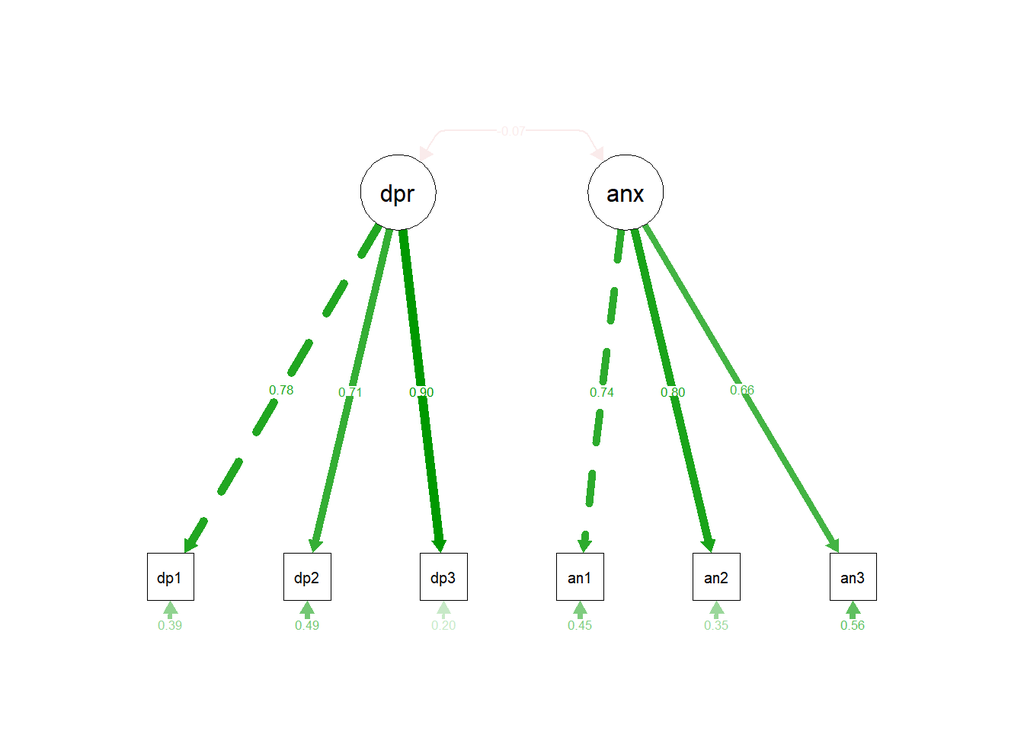

```r
# 可视化
library(semPlot)
semPlot::semPaths(cfa_fit, what = "std", style = "lisrel",
                   title = TRUE, curvePivot = TRUE)
```

## 8.3 结构模型与模型拟合评价

### 意义与使用场景

**核心意义**：结构模型将测量模型和路径分析结合，研究潜变量之间的因果关系，模型拟合评价验证模型与数据的匹配程度。

**举例**：研究生活质量、心理健康等潜变量与疾病预后的关系

**为什么这种数据适合用结构方程模型？**

首先，生活质量、心理健康等构念无法直接观测，需要通过多个指标测量（潜变量）。其次，这些潜变量之间存在因果关系，需要同时建模测量模型和结构模型。结构方程模型能够结合测量模型（因子分析）和结构模型（路径分析），是研究潜变量因果关系的理想方法。

**研究目的是什么？**

本研究有三个层次的目的：1. 建立测量模型：验证各潜变量的测量结构；2. 检验因果路径：分析潜变量之间的因果关系；3. 评估模型拟合：判断模型与数据的匹配程度。

**可能得到什么样的结果？**

假设结构方程模型显示：抑郁→焦虑β=0.45（p<0.001），CFI=0.96，RMSEA=0.04。

1. 结构效应：抑郁对焦虑的效应β=0.45，抑郁水平越高，焦虑水平越高。
2. 测量模型：各潜变量的因子载荷>0.6，测量模型拟合良好。
3. 模型拟合：CFI=0.96>0.95，RMSEA=0.04<0.06，模型拟合优秀。
4. 解释力：抑郁解释了焦虑变异的20%，还有其他因素影响焦虑。

**需要注意什么？**

结构方程模型的结果依赖于模型的正确设定，统计拟合好不代表因果正确。模型拟合指数的判断需综合考虑多个指标，单一指标可能误导。样本量要求较高，一般建议至少10倍于自由参数数量。修正模型（如增加路径）需有理论依据，避免过度拟合。

### 数学基础

**完整SEM模型**：

**测量模型**：
$$\mathbf{X} =
\mathbf{\Lambda}_x\mathbf{\xi} + \mathbf{\delta}$$
$$\mathbf{Y} = \mathbf{\Lambda}_y\mathbf{\eta} +
\mathbf{\varepsilon}$$

**结构模型**：
$$\mathbf{\eta} = \mathbf{B}\mathbf{\eta} +
\mathbf{\Gamma}\mathbf{\xi} + \mathbf{\zeta}$$

**拟合指数**：

| 指标 | 可接受标准 | 说明 |
| --- | --- | --- |
| $\chi^2$/df | < 3 | 卡方与自由度比 |
| CFI | > 0.90 | 比较拟合指数 |
| TLI | > 0.90 | Tucker-Lewis指数 |
| RMSEA | < 0.08 | 近似误差均方根 |
| SRMR | < 0.08 | 标准化残差均方根 |

### 代码实现

```r
# 定义完整SEM模型
sem_model <- '
  # 测量模型
  depression =~ dep1 + dep2 + dep3
  anxiety =~ anx1 + anx2 + anx3

  # 结构模型（假设抑郁影响焦虑）
  anxiety ~ depression
'

# 拟合SEM模型
sem_fit <- lavaan::sem(sem_model, data = cfa_data)
summary(sem_fit, fit.measures = TRUE, standardized = TRUE)
```

```
## lavaan 0.6-21 ended normally after 22 iterations
##
##   Estimator                                         ML
##   Optimization method                           NLMINB
##   Number of model parameters                        13
##
##   Number of observations                           300
##
## Model Test User Model:
##
##   Test statistic                                 3.357
##   Degrees of freedom                                 8
##   P-value (Chi-square)                           0.910
##
## Model Test Baseline Model:
##
##   Test statistic                               628.869
##   Degrees of freedom                                15
##   P-value                                        0.000
##
## User Model versus Baseline Model:
##
##   Comparative Fit Index (CFI)                    1.000
##   Tucker-Lewis Index (TLI)                       1.014
##
## Loglikelihood and Information Criteria:
##
##   Loglikelihood user model (H0)              -2233.066
##   Loglikelihood unrestricted model (H1)      -2231.387
##
##   Akaike (AIC)                                4492.131
##   Bayesian (BIC)                              4540.281
##   Sample-size adjusted Bayesian (SABIC)       4499.052
##
## Root Mean Square Error of Approximation:
##
##   RMSEA                                          0.000
##   90 Percent confidence interval - lower         0.000
##   90 Percent confidence interval - upper         0.027
##   P-value H_0: RMSEA <= 0.050                    0.989
```

[output cut: 23 more lines]

```
## Regressions:
##                    Estimate  Std.Err  z-value  P(>|z|)   Std.lv  Std.all
##   anxiety ~
##     depression       -0.063    0.062   -1.015    0.310   -0.071   -0.071
##
## Variances:
##                    Estimate  Std.Err  z-value  P(>|z|)   Std.lv  Std.all
##    .dep1              0.421    0.051    8.186    0.000    0.421    0.389
##    .dep2              0.503    0.051    9.886    0.000    0.503    0.492
##    .dep3              0.195    0.049    3.975    0.000    0.195    0.195
##    .anx1              0.427    0.057    7.538    0.000    0.427    0.450
##    .anx2              0.368    0.065    5.677    0.000    0.368    0.354
##    .anx3              0.488    0.051    9.492    0.000    0.488    0.562
##     depression        0.662    0.090    7.353    0.000    1.000    1.000
##    .anxiety           0.520    0.082    6.338    0.000    0.995    0.995
```

```r
# 提取拟合指数
fit_indices <- fitmeasures(sem_fit, c("chisq", "df", "pvalue", "cfi", "tli", "rmsea", "srmr"))
cat("\n========== 模型拟合指数 ==========\n")
```

```
##
## ========== 模型拟合指数 ==========
```

```r
print(round(fit_indices, 3))
```

```
##  chisq     df pvalue    cfi    tli  rmsea   srmr
##  3.357  8.000  0.910  1.000  1.014  0.000  0.018
```

```r
# 修正指数
mi <- modificationIndices(sem_fit)
head(mi[order(mi$mi, decreasing = TRUE), ], 10)
```

```
##           lhs op  rhs    mi    epc sepc.lv sepc.all sepc.nox
## 36       anx2 ~~ anx3 1.551  0.605   0.605    1.426    1.426
## 16 depression =~ anx1 1.551 -0.075  -0.061   -0.063   -0.063
## 29       dep2 ~~ anx2 0.908  0.032   0.032    0.075    0.075
## 26       dep1 ~~ anx3 0.828  0.029   0.029    0.064    0.064
## 35       anx1 ~~ anx3 0.642 -0.320  -0.320   -0.702   -0.702
## 17 depression =~ anx2 0.642  0.051   0.042    0.041    0.041
## 30       dep2 ~~ anx3 0.542 -0.025  -0.025   -0.050   -0.050
## 24       dep1 ~~ anx1 0.499 -0.022  -0.022   -0.053   -0.053
## 20    anxiety =~ dep2 0.247  0.035   0.025    0.025    0.025
## 23       dep1 ~~ dep3 0.247 -0.355  -0.355   -1.241   -1.241
```

## 8.4 潜变量增长模型

### 意义与使用场景

**核心意义**：潜变量增长模型研究潜变量随时间的变化轨迹，可分析个体差异和预测因子。

**举例**：研究患者生活质量随时间的变化轨迹

**为什么这种数据适合用潜变量增长模型？**

首先，生活质量是纵向测量的，需要分析其随时间的变化趋势。其次，不同患者的初始水平和变化速度可能不同，存在个体差异。潜变量增长模型能够估计总体的变化轨迹（截距和斜率的均值）和个体差异（截距和斜率的方差），是分析纵向数据的理想方法。

**研究目的是什么？**

本研究有三个层次的目的：1. 估计变化轨迹：分析生活质量随时间的平均变化趋势；2. 分析个体差异：判断患者之间的初始水平和变化速度是否存在差异；3. 识别预测因子：分析哪些因素影响初始水平和变化速度。

**可能得到什么样的结果？**

假设潜变量增长模型显示：截距均值=50，斜率均值=3，截距方差=80，斜率方差=5。

1. 平均轨迹：初始生活质量平均为50分，每期增加3分，呈上升趋势。
2. 个体差异：截距方差=80（p<0.001），斜率方差=5（p=0.02），患者间存在显著差异。
3. 相关性：截距与斜率相关r=-0.3，初始水平低的患者改善更快。
4. 预测因子：年龄负向预测斜率（β=-0.1），年轻患者改善更快。

**需要注意什么？**

潜变量增长模型假设线性增长轨迹，若增长非线性需使用非线性增长模型或分段模型。需要至少3个时间点的数据才能估计增长模型。模型拟合可通过CFI、RMSEA等指标评估。截距与斜率的相关性有重要临床意义：负相关表示”追赶效应”，正相关表示”马太效应”。

**潜变量增长模型（LGM）**：

研究潜变量随时间的变化轨迹。

**模型形式**：

$$Y_{it} = \eta_{0i} + \eta_{1i} \cdot
\lambda_t + \varepsilon_{it}$$

**参数说明**： - $\eta_{0i}$：个体$i$的初始水平（截距因子） - $\eta_{1i}$：个体$i$的增长率（斜率因子） - $\lambda_t$：时间得分

### 代码实现

```r
# 模拟纵向数据
set.seed(555)
n_lgm <- 200

# 潜变量：截距和斜率
eta0 <- rnorm(n_lgm, 50, 10)   # 初始水平
eta1 <- rnorm(n_lgm, 5, 2)     # 增长率

# 4个时间点的观测
y1 <- eta0 + rnorm(n_lgm, 0, 5)
y2 <- eta0 + eta1 * 1 + rnorm(n_lgm, 0, 5)
y3 <- eta0 + eta1 * 2 + rnorm(n_lgm, 0, 5)
y4 <- eta0 + eta1 * 3 + rnorm(n_lgm, 0, 5)

lgm_data <- data.frame(y1, y2, y3, y4)

# 定义LGM模型
lgm_model <- '
  # 截距因子
  i =~ 1*y1 + 1*y2 + 1*y3 + 1*y4
  # 斜率因子
  s =~ 0*y1 + 1*y2 + 2*y3 + 3*y4
'

# 拟合模型
lgm_fit <- lavaan::growth(lgm_model, data = lgm_data)
summary(lgm_fit, standardized = TRUE)
```

```
## lavaan 0.6-21 ended normally after 101 iterations
##
##   Estimator                                         ML
##   Optimization method                           NLMINB
##   Number of model parameters                         9
##
##   Number of observations                           200
##
## Model Test User Model:
##
##   Test statistic                                10.711
##   Degrees of freedom                                 5
##   P-value (Chi-square)                           0.057
##
## Parameter Estimates:
##
##   Standard errors                             Standard
##   Information                                 Expected
##   Information saturated (h1) model          Structured
##
## Latent Variables:
##                    Estimate  Std.Err  z-value  P(>|z|)   Std.lv  Std.all
##   i =~
##     y1                1.000                              10.165    0.908
##     y2                1.000                              10.165    0.884
##     y3                1.000                              10.165    0.841
##     y4                1.000                              10.165    0.768
##   s =~
##     y1                0.000                               0.000    0.000
##     y2                1.000                               2.386    0.208
##     y3                2.000                               4.771    0.395
##     y4                3.000                               7.157    0.541
##
## Covariances:
##                    Estimate  Std.Err  z-value  P(>|z|)   Std.lv  Std.all
##   i ~~
##     s                -0.500    2.785   -0.180    0.857   -0.021   -0.021
##
## Intercepts:
##                    Estimate  Std.Err  z-value  P(>|z|)   Std.lv  Std.all
##     i                50.304    0.772   65.168    0.000    4.949    4.949
##     s                 4.857    0.226   21.450    0.000    2.036    2.036
##
## Variances:
##                    Estimate  Std.Err  z-value  P(>|z|)   Std.lv  Std.all
##    .y1               22.133    4.923    4.496    0.000   22.133    0.176
##    .y2               24.109    3.285    7.339    0.000   24.109    0.182
##    .y3               21.843    3.265    6.689    0.000   21.843    0.150
##    .y4               23.494    5.407    4.345    0.000   23.494    0.134
##     i               103.334   12.177    8.486    0.000    1.000    1.000
##     s                 5.691    1.248    4.561    0.000    1.000    1.000
```

```r
# 提取截距和斜率的均值与方差
parameterEstimates(lgm_fit)[1:4, ]
```

```
##   lhs op rhs est se  z pvalue ci.lower ci.upper
## 1   i =~  y1   1  0 NA     NA        1        1
## 2   i =~  y2   1  0 NA     NA        1        1
## 3   i =~  y3   1  0 NA     NA        1        1
## 4   i =~  y4   1  0 NA     NA        1        1
```

## 第八章小结

### 核心知识点总结

| 主题 | 核心内容 | 关键函数 |
| --- | --- | --- |
| 路径分析 | 因果关系网络 | `lavaan::sem()` |
| CFA | 潜变量测量模型 | `lavaan::cfa()` |
| SEM | 测量+结构模型 | `lavaan::sem()` |
| 拟合评价 | CFI、RMSEA等 | `fitmeasures()` |
| LGM | 潜变量增长轨迹 | `lavaan::growth()` |

# 第九章：非参数与半参数回归

非参数回归不假设特定的函数形式，让数据”说话”，适用于探索变量间的复杂关系。本章将系统讲解核密度估计、局部回归、样条回归、广义加性模型等内容。

## 9.1 核密度估计

### 意义与使用场景

**核心意义**：核密度估计是一种非参数方法，用于估计数据的概率密度函数，无需假设特定分布形式。

**举例**：分析患者血压的分布特征

**为什么这种数据适合用核密度估计？**

首先，血压的分布可能不是标准的正态分布，可能存在偏态或多峰。其次，我们需要直观展示血压的分布形态，发现潜在的亚群（如双峰分布可能提示两个亚群）。核密度估计是非参数方法，无需假设特定分布形式，能够灵活地估计数据的真实分布形态。

**研究目的是什么？**

本研究有三个层次的目的：1. 探索分布形态：判断血压是否服从正态分布，是否存在偏态或多峰；2. 比较群体差异：比较不同群体（如男女、不同年龄组）的分布差异；3. 发现亚群：若分布呈多峰，可能提示存在不同的亚群。

**可能得到什么样的结果？**

假设核密度估计显示：血压分布呈轻微右偏，存在一个主峰和一个肩峰。

1. 分布形态：血压分布呈轻微右偏，均值略高于中位数，高值尾部较长。
2. 正态性检验：Shapiro-Wilk检验p<0.001，拒绝正态假设，核密度估计更准确。
3. 亚群提示：分布存在肩峰，可能提示高血压亚群的存在。
4. 群体比较：男性血压分布整体右移，均值比女性高5mmHg。

**需要注意什么？**

核密度估计的结果依赖于带宽的选择：带宽过小导致过拟合（噪声多），带宽过大导致欠拟合（过度平滑）。建议使用交叉验证或Silverman规则选择最优带宽。核函数的选择（如高斯核、Epanechnikov核）对结果影响较小。对于多峰分布，需谨慎解释是否真实存在亚群。

### 数学基础

**核密度估计（KDE）**：

$$\hat{f}(x) = \frac{1}{nh}\sum_{i=1}^{n}
K\left(\frac{x - X_i}{h}\right)$$

**参数说明**： - $K(\cdot)$：核函数（如高斯核、Epanechnikov核） - $h$：带宽（平滑参数）

**带宽选择**：

| 方法 | 特点 |
| --- | --- |
| Silverman法则 | $h = 1.06 \sigma n^{-1/5}$ |
| 交叉验证 | 最小化积分平方误差 |
| Sheather-Jones | 自适应带宽选择 |